# Week 11: Correlations

11/16/2018

## Outline

```r
library(ggplot2)
```

- Calculating correlation coefficient (Pearson and Spearman)
- Doing correlation test (Pearson and Spearman)
- Bi-variate scatter plots
- Anscombe's quartet
- Using `stat_summary()` in `ggplot2`

## Correlation Coefficients

## Correlation Coefficients

- `cor()` takes two vectors and returns a correlation coefficient
- Default is Pearson
- Get Spearman correlation coefficient with `method = "spearman"`

```r
cor(trees$Girth, trees$Height)
```

```
## [1] 0.5192801
```

```r
cor(trees$Girth, trees$Height, method = "spearman")
```

```
## [1] 0.4408387
```

## Correlation Coefficients

- Order of two vectors doesn't matter.

```r
cor(trees$Height, trees$Girth)
```

```
## [1] 0.5192801
```

## Correlation Test

## Correlation Test

- `cor.test()` takes two vectors and does a correlation test.
- "`alternative =`" controls tails (`"two.sided"` is default)

```r
cor.test(trees$Height, trees$Girth)
```

```
##
##  Pearson's product-moment correlation
##
## data:  trees$Height and trees$Girth
## t = 3.2722, df = 29, p-value = 0.002758
## alternative hypothesis: true correlation is not equal to 0
## 95 percent confidence interval:
##  0.2021327 0.7378538
## sample estimates:
##       cor
## 0.5192801
```

## Correlation Test

- `method = "spearman"` for Spearman correlation
- Safe to ignore message: "Cannot compute exact p-value with ties"

```r
cor.test(trees$Height, trees$Girth, method = "spearman")
```

```
##
##  Spearman's rank correlation rho
##
## data:  trees$Height and trees$Girth
## S = 2773.4, p-value = 0.01306
## alternative hypothesis: true rho is not equal to 0
## sample estimates:
##       rho
## 0.4408387
```

## Bi-variate Scatter Plots

## Scatterplots in ggplot2

- Both `x` and `y` `aes`thetics need to be continuous
- `geom_point()` plots points

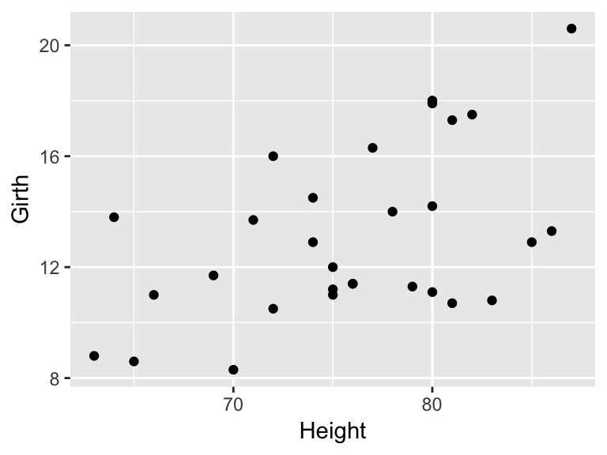

```r
ggplot(trees, aes(x = Height, y = Girth)) + geom_point()
```

## Scatterplots in ggplot2

- OK to use either variable for the x-axis for correlations.
- You can put `aes()` either inside of `ggplot()` or inside of a `geom`

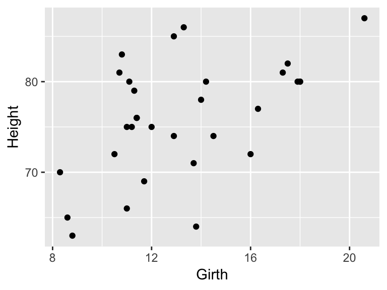

```r
ggplot(trees) + geom_point(aes(x = Girth, y = Height))
```

## Scatterplots in ggplot2

- Use `size =` outside of `aes()` to change the size of all points

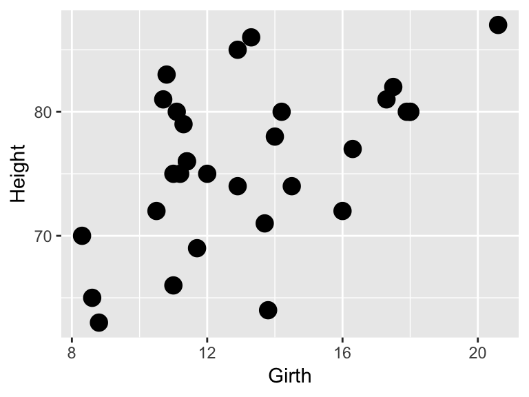

```r
ggplot(trees) + geom_point(aes(x = Girth, y = Height), size = 4)
```

## Scatterplots in ggplot2

- Put `size =` *inside* of `aes()` to map a variable to point size.
- You probably won't have a use for this in this class.

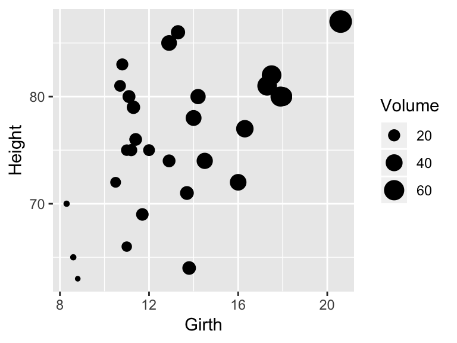

```r
ggplot(trees) + geom_point(aes(x = Girth, y = Height, size = Volume))
```

## Customizing plots

## Save previous plot

```r
p <- ggplot(trees) + geom_point(aes(x = Girth, y = Height, size = Volume))
```

## Finishing up your scatter plot

- Add units to axis labels
- (and to size legend)

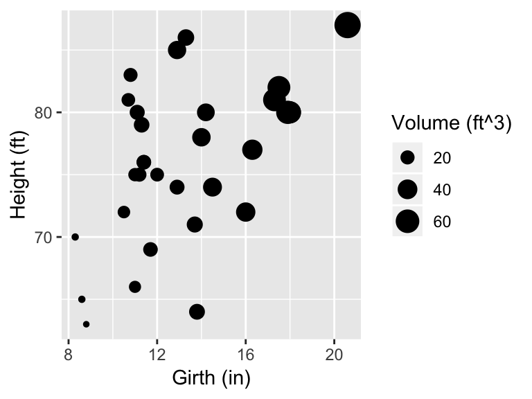

```r
p2 <- p +
  labs(x = "Girth (in)", y = "Height (ft)") +
  scale_size_continuous("Volume (ft^3)")
p2
```

## Finishing up your scatter plot

- Try out a different `theme_*()`
- Type theme_ and browse the dropdown menu to try some out.

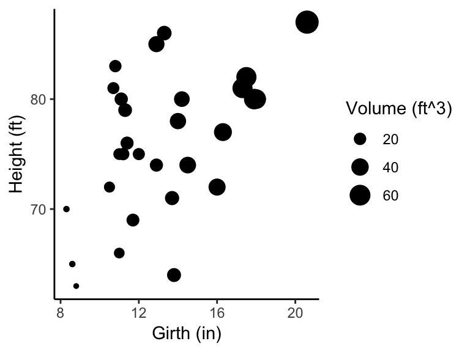

```r
p2 + theme_classic()
```

## Anscombe's quartet

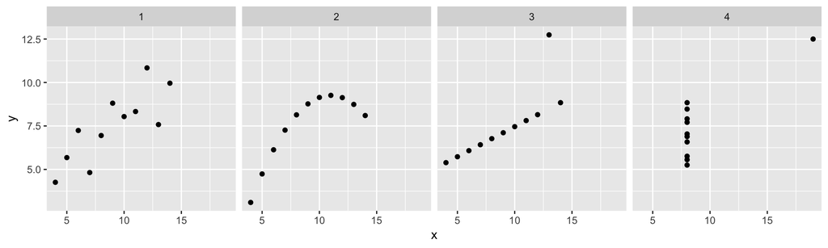

## Anscombe's Quartet

- Anscombe's Quartet is a group of 4 bi-variate datasets
- Similar mathematical properties despite very different shapes
- Data visualization is important!
- Available as `anscombe` in R
- Even more mathematically similar and visually different datasets in the `datasauRus` package!

## Anscombe's Quartet

For your assigned set of x and y variables:

- Calculate the Pearson Spearman correlation coefficients
- Do a correlation test (just get the p-value, not all 6 steps)
- Make a bi-variate scatter plot
- Compare with another student

```r
anscombe
```

| x1 | x2 | x3 | x4 | y1 | y2 | y3 | y4 |
| --- | --- | --- | --- | --- | --- | --- | --- |
| 10 | 10 | 10 | 8 | 8.04 | 9.14 | 7.46 | 6.58 |
| 8 | 8 | 8 | 8 | 6.95 | 8.14 | 6.77 | 5.76 |
| 13 | 13 | 13 | 8 | 7.58 | 8.74 | 12.74 | 7.71 |
| 9 | 9 | 9 | 8 | 8.81 | 8.77 | 7.11 | 8.84 |
| 11 | 11 | 11 | 8 | 8.33 | 9.26 | 7.81 | 8.47 |
| 14 | 14 | 14 | 8 | 9.96 | 8.10 | 8.84 | 7.04 |
| 6 | 6 | 6 | 8 | 7.24 | 6.13 | 6.08 | 5.25 |
| 4 | 4 | 4 | 19 | 4.26 | 3.10 | 5.39 | 12.50 |
| 12 | 12 | 12 | 8 | 10.84 | 9.13 | 8.15 | 5.56 |
| 7 | 7 | 7 | 8 | 4.82 | 7.26 | 6.42 | 7.91 |

[output cut: 1 more lines]

## `datasauRus`

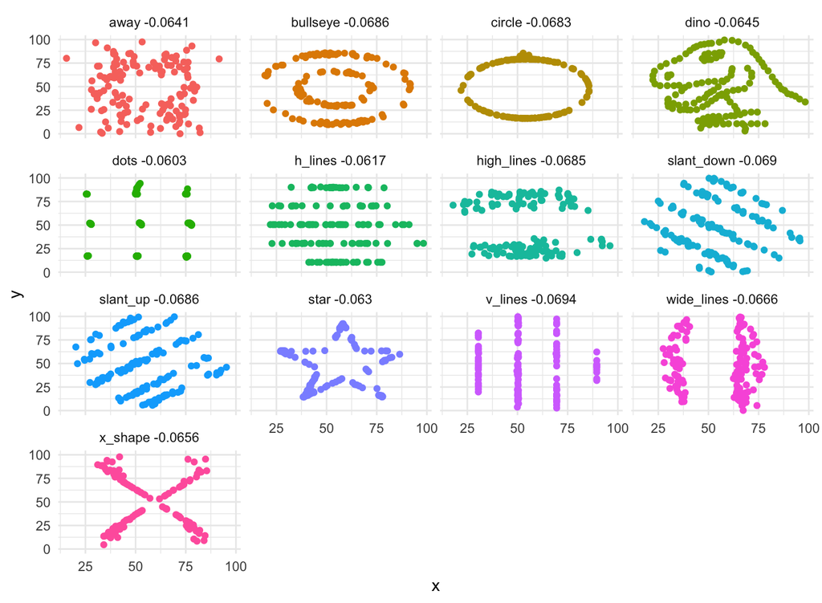

## What now?

Work on homework?

*OR*

Go through a *way* quicker way to make bar plots and add significance letters?

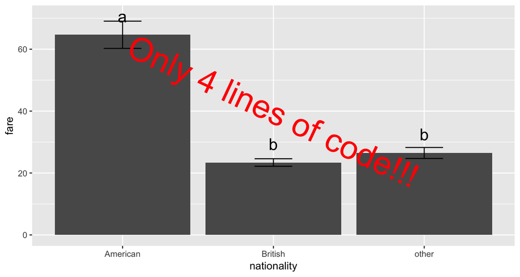

## Making complex plots simple with `stat_summary()`

## What's a `stat`?

- "geoms" add mapping to geometric features (e.g points, lines, bars)
- "stats" do some transformation.
- E.g. `geom_boxplot()` uses `stat = "boxplot"` by default. Takes dataframe and calculates quartiles, fences, outliers.
- `geom_point()` uses `stat = "identity"` by default. Simply passes x and y unchanged.

## Adding a stat

- Some geoms can take different stats, but usually not a good idea to change the default.
- You *can* add a `stat_*()` instead of adding a `geom_*()`
- E.g. instead of:

```r
p + geom_boxplot(stat = "boxplot")
```

- You could do:

```r
p + stat_boxplot(geom = "boxplot")
```

- These are identical, no reason to *actually* do this.

## stat_summary() is flexible!

- Tell it how you want it to summarize your data frame and what geom you want it to use
- Remember bar plots? First we summarized the data using `group_by(...) %>% summarize(...)`, then we plotted the summary data frame.
- With `stat_summary()` instead:

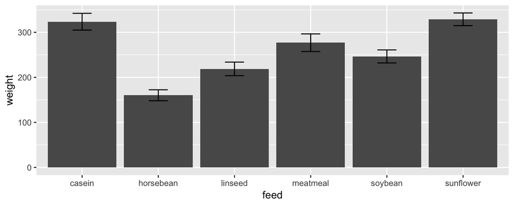

```r
ggplot(chickwts, aes(x = feed, y =  weight)) +
  stat_summary(geom = "bar", fun.y = "mean") + # makes the bars
  stat_summary(geom = "errorbar", fun.data = "mean_se", width = 0.25) # makes the errorbars
```

## stat_summary()

```r
ggplot(chickwts, aes(x = feed, y =  weight)) +
  stat_summary(geom = "bar", fun.y = "mean") # use x = feed, but y = mean(weight)
```

- `geom = "bar"` tells it to use `geom_bar()`
- `fun.y` is telling it how to get the y-values that `geom_bar()` needs. Here, we used `mean()`
- Try changing `fun.y` to something else like `min`, `max`, or `median`.

## stat_summary()

```r
ggplot(chickwts, aes(x = feed, y =  weight)) +
  stat_summary(geom = "bar", fun.y = "mean") +
  stat_summary(geom = "errorbar", fun.data = "mean_se")
# use x = feed, but ymin = mean(weight) - SEM, ymax = mean(weight) + SEM
```

- `geom = "errorbar"` tells it to use `geom_errorbar()`
- `mean_se` is a function from `ggplot2` that calculates ymin, and ymax aesthetics needed for errorbars.
- `fun.data` because `mean_se` returns a dataframe, not just the y-values

## Boxplots with letters using `stat_summary()`

- We can use `stat_summary()` to add letters to boxplots without making a new data frame

```r
titanic <- read.csv("titanic.csv") %>% filter(fare < 400)
p <- ggplot(titanic, aes(x = nationality, y = fare)) + geom_boxplot()
```

## Base boxplot

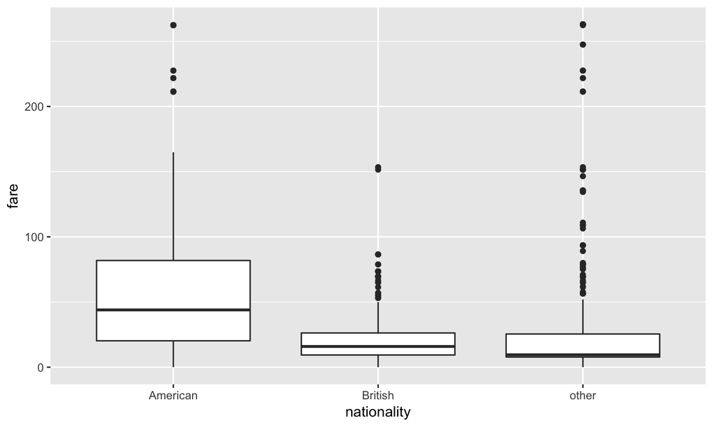

```r
p
```

## Adding letters with `stat_summary()`

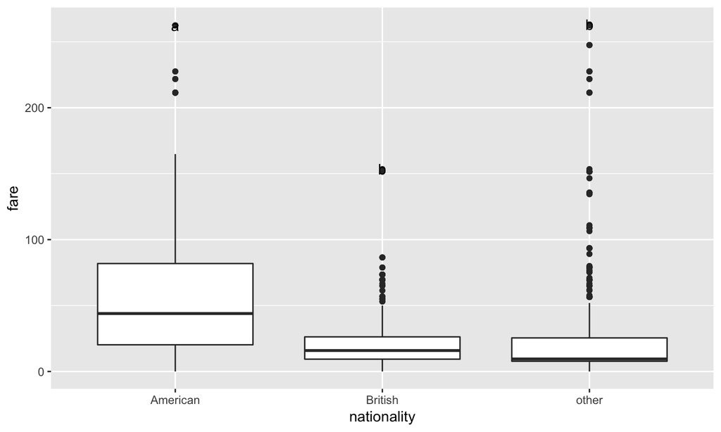

```r
p + stat_summary(geom = "text", fun.y = "max", label = c("a", "b", "b"))
```

## Adjust letter position

- Nudge the letters up with `position = position_nudge()`

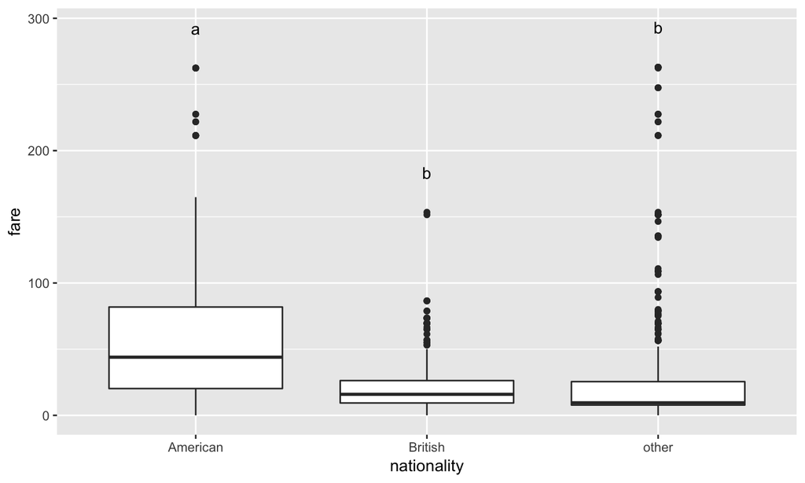

```r
p + stat_summary(geom = "text", fun.y = "max", label = c("a", "b", "b"),
                 position = position_nudge(y = 30)) #in units of y-axis
```

## Change the look of letters

- additional arguments get passed to `geom_text()`

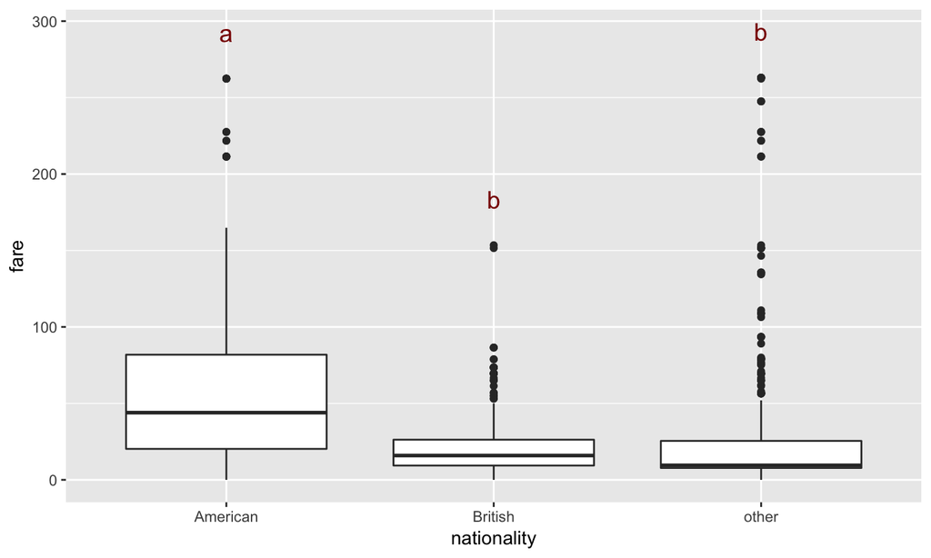

```r
p + stat_summary(geom = "text", fun.y = "max", label = c("a", "b", "b"),
                 position = position_nudge(y = 30), #in units of y-axis
                 size = 5, color = "darkred")
```

## Using `stat_summary()` in practice

- Making a summary table first, then plotting may be more *transparent*, easier for others to understand
- *But*, `stat_summary()` can make code cleaner, easier to read
- Complex plots with original data with multiple summary annotations (e.g. means, errorbars, significance letters) are made a **lot** simpler with `stat_summary()`